# **Module Computer Experiments, INSA de Toulouse**

## *Novembre 2020*

# TP3 sur l'analyse de sensibilité

# SOLUTION

## 1. Présentation du modèle de crues

On souhaite protéger une zone de crue à l'aide d'une digue. Pour cela, on considère un modèle hydraulique simplifié.

[figure not shown]

On s'intéresse dans un premier temps à la surverse $S$ (en $m$) qui est la différence entre la hauteur d'eau et la hauteur de la digue :

$$ S=Z_v+H-H_d-C_b \ avec \ H= \left( \frac{Q}{BK_s \sqrt{\frac {Z_m-Z_v}{L}}} \right)^{0.6} $$

Où :

- $H$ est la hauteur d'eau
- $Q$ est le débit de la rivière
- $K_s$ est le coefficient de Strickler (coefficient de frottement)
- $Z_v$ est la côte du fond du cours d'eau en aval du tronçon
- $Z_m$ est la côte du fond du cours d'eau en amont du tronçon
- $H_d$ est la hauteur de la digue
- $C_b$ est la côte de la berge
- $L$ est la longueur du tronçon étudié
- $B$ est la largeur du cours d'eau.

On s'intéresse dans un second temps au coût annuel d'entretien de la digue $C_{digue}$ (en $M$ euros) :

$$ C_{digue}=\mathbb{1}_{S>0} + \left[0.2+0.8 \left(1-exp \left (- \frac {1000}{S^4}\right)\right)\right]\mathbb{1}_{S\le0}+\frac{1}{20} \left(H_d \mathbb{1}_{H_d>8}+8 \, \mathbb{1}_{H_d\le8}\right).$$

Pour les études déterministes (cumul quadratique), les valeurs nominales et écart-types des variables d'entrée sont les suivantes :

[output not shown]

Pour les études probabilistes, on considère que les variables d'entrée sont indépendantes et suivent les lois de probabilités suivantes :

[output not shown]

## Objectifs du TP

On souhaite comparer les différentes méthodes d'analyse de sensibilité vues en cours sur le modèle de crues. On s'interessera de manière indépendante aux deux sorties du modèle : la surverse $S$ et le coût d'entretien de la digue $C_{digue}$.

### Préambule

Le modèle de crues est implémenté dans le fichier `Fcrues.R`, à travers la fonction du même nom qui renvoie pour un jeu de valeurs des 8 variables d'entrée les deux variables de sortie $S$ et $C_{digue}$.  
Le fichier `EchantFcrues.R` contient une fonction de même nom qui permet de simuler des échantillons des variables d'entrée suivant leur loi de probabilité.  
Vous pouvez éditer ces fichiers pour bien comprendre leur contenu. Dans la cellule qui suit, ces deux fichiers seront chargés (fonction `source`) afin d'utiliser les fonctions qu'ils contiennent. Des exemples d'utilisation des fonctions sont aussi donnés pour vous familiariser avec leur utilisation.

```r
rm(list=ls())
graphics.off()

# Chargement des packages et fonctions utilises
# install.packages('sensitivity', repos='http://cran.us.r-project.org')
# install.packages('evd', repos='http://cran.us.r-project.org')
# install.packages('triangle', repos='http://cran.us.r-project.org')
# install.packages('tidyverse', repos='http://cran.us.r-project.org')

library(sensitivity)   # Methodes d'analyse de sensibilite
library(evd)           # Pour avoir loi Gumbel
library(triangle)      # Pour avoir la loi triangulaire
library(tidyverse)     # pour aider à l'affichage des résultats
source("truncated.R")  # Definit quelques lois tronquees

# Initialisation de la graine du generateur aleatoire (reproductibilite des resultats)
set.seed(12345)

#-----------------------------------------------------------------------------#
# Chargement des fonctions crues
source("Fcrues.R")
source("EchantFcrues.R")

#-----------------------------------------------------------------------------#
# Initialisation des parametres des lois des variables d'entrée
d <- 8 # nombre de variables incertaines
names <- c("Q","Ks","Zv","Zm","Hd","Cb","L","B") # noms de variables aleatoires

# Valeur nominale et incertitude (ecart-type) des entrees incertaines
Q  <- 1335 ; sigQ  <- 562   # debit
Ks <- 30   ; sigKs <- 7.43     # coef de frottement
Zv <- 50   ; sigZv <- 0.41  # cote fond aval
Zm <- 55   ; sigZm <- 0.41  # cote font amont
Hd <- 8    ; sigHd <- sqrt(1/3)   # hauteur de la digue
Cb <- 55.5 ; sigCb <- 0.205 # cote de la berge
L <- 5000  ; sigL  <- 4.1   # longueur de la riviere
B <- 300   ; sigB  <- 2.05  # largeur de la riviere

# Valeurs minimales et maximales
# pour la borne sup de Ks , on prend le quantile a  95%
binf=c(500,15,49,54,7,55,4990,295)
bsup=c(3000,43.3,51,56,9,56,5010,305)

#-----------------------------------------------------------------------------#
# Exemple d'utilisation de Fcrues(x)
# evaluation de la fonction au point nominal
x <- t(c(Q,Ks,Zv,Zm,Hd,Cb,L,B))
out <- Fcrues(x)  # Calcul du modèle de crues : fonction Fcrue renvoie les 2 reponses
out1 <- Fcrues(x,ans=1)  # Evaluation de la surverse uniquement
out2 <- Fcrues(x,ans=2)  # Evaluation du cout uniquement

#Fonctions servant à un affichage ergonomique
x_lettre=paste(x,collapse = ", ")
print(paste("x = ",x_lettre ))
str_glue("S={out1}, ","Cp={out2}")

# Exemple d'utilisation de EchantFcrues(n)
# Génération d'un échantillon de taille n des 8 variables d'entrées
n = 10
cat("##############################################################################\n")
cat("-------->  Génération d'un échantillon aléatoire de taille n = ",n," \n")
x =  EchantFcrues(n) # x : matrice nx8
print(x)
cat("\n --------> Résumé statistique de l'échantillon")
summary(x) # résumé statistique du jeu de variables d'entrée
```

```
[1] "x =  1335, 30, 50, 55, 8, 55.5, 5000, 300"
```

'S=-10.9721968322264, Cp=0.653335874137682'

```
##############################################################################
-------->  Génération d'un échantillon aléatoire de taille n =  10
           [,1]     [,2]     [,3]     [,4]     [,5]     [,6]     [,7]     [,8]
 [1,] 1642.3343 17.81617 49.95260 55.35658 8.564387 55.86672 5003.543 301.0526
 [2,] 2074.4163 22.62013 49.80840 54.10943 7.858398 55.70615 4997.193 300.0277
 [3,] 1732.2027 35.23883 50.73700 54.61272 8.854548 55.39688 5008.326 299.3182
 [4,] 2115.7076 15.12629 50.23512 55.20230 8.546486 55.32636 5003.027 299.0976
 [5,] 1198.2412 28.17364 50.15684 54.86035 7.519362 55.63428 5007.989 296.5532
 [6,]  797.5137 29.57534 49.88298 54.85044 7.642449 55.49962 4996.617 300.6351
 [7,] 1017.6799 28.11253 50.22353 55.48774 7.120390 55.63242 5006.797 303.6116
 [8,] 1274.7212 28.39810 50.04507 55.56218 7.086913 55.20042 4995.467 300.8465
 [9,] 1656.8932 23.37840 49.67300 55.12527 7.110108 55.46665 5001.060 300.0517
[10,] 2839.8171 43.40778 49.98444 54.51775 8.251086 55.34393 5006.727 297.7395

 --------> Résumé statistique de l'échantillon
```

```
       V1               V2              V3              V4
 Min.   : 797.5   Min.   :15.13   Min.   :49.67   Min.   :54.11
 1st Qu.:1217.4   1st Qu.:22.81   1st Qu.:49.90   1st Qu.:54.67
 Median :1649.6   Median :28.14   Median :50.01   Median :54.99
 Mean   :1635.0   Mean   :27.18   Mean   :50.07   Mean   :54.97
 3rd Qu.:1988.9   3rd Qu.:29.28   3rd Qu.:50.21   3rd Qu.:55.32
 Max.   :2839.8   Max.   :43.41   Max.   :50.74   Max.   :55.56
       V5              V6              V7             V8
 Min.   :7.087   Min.   :55.20   Min.   :4995   Min.   :296.6
 1st Qu.:7.220   1st Qu.:55.36   1st Qu.:4998   1st Qu.:299.2
 Median :7.750   Median :55.48   Median :5003   Median :300.0
 Mean   :7.855   Mean   :55.51   Mean   :5003   Mean   :299.9
 3rd Qu.:8.473   3rd Qu.:55.63   3rd Qu.:5007   3rd Qu.:300.8
 Max.   :8.855   Max.   :55.87   Max.   :5008   Max.   :303.6
```

## 2. Cumul quadratique

Calculer les facteurs d'importance des entrées sur la surverse $S$ par la formule du cumul quadratique. Pour calculer les dérivées, on pourra :

- Soit utiliser les différences finies (avec par exemple une perturbation de 1)
- Soit utiliser les dérivées exactes en dérivant formellement le modèle de crues à l'aide de la fonction `deriv()` et en récupérant les dérivées par la fonction `eval()`.

On conseille d'utiliser la deuxième méthode qui est beaucoup moins lourde à mettre en oeuvre. On rappelle l'expression des indices de sensibilité (normés) d'une fonction $g(X)$ obtenus par cumul quadratique autour du point nominal $X_{nom}$ :

$$\eta_{X_i}^2=\frac {1}{var(Y)}\left(\frac {\partial g}{\partial X_{i}}(X_{nom})\right)^2 \sigma_{X_i}^2 \, \text{(Si les $X_i$ sont indépendants)} $$

```r
# Approximation des dérivées par differences finies (DF)
eps <- 0.01 # perturbation de 1%

xinfQ <- t(c(Q-Q*eps,Ks,Zv,Zm,Hd,Cb,L,B))   ; xsupQ <- t(c(Q+Q*eps,Ks,Zv,Zm,Hd,Cb,L,B))
xinfKs <- t(c(Q,Ks-Ks*eps,Zv,Zm,Hd,Cb,L,B)) ; xsupKs <- t(c(Q,Ks+Ks*eps,Zv,Zm,Hd,Cb,L,B))
xinfZv <- t(c(Q,Ks,Zv-Zv*eps,Zm,Hd,Cb,L,B)) ; xsupZv <- t(c(Q,Ks,Zv+Zv*eps,Zm,Hd,Cb,L,B))
xinfZm <- t(c(Q,Ks,Zv,Zm-Zm*eps,Hd,Cb,L,B)) ; xsupZm <- t(c(Q,Ks,Zv,Zm+Zm*eps,Hd,Cb,L,B))
xinfHd <- t(c(Q,Ks,Zv,Zm,Hd-Hd*eps,Cb,L,B)) ; xsupHd <- t(c(Q,Ks,Zv,Zm,Hd+Hd*eps,Cb,L,B))
xinfCb <- t(c(Q,Ks,Zv,Zm,Hd,Cb-Cb*eps,L,B)) ; xsupCb <- t(c(Q,Ks,Zv,Zm,Hd,Cb+Cb*eps,L,B))
xinfL <- t(c(Q,Ks,Zv,Zm,Hd,Cb,L-L*eps,B)) ; xsupL <- t(c(Q,Ks,Zv,Zm,Hd,Cb,L+L*eps,B))
xinfB <- t(c(Q,Ks,Zv,Zm,Hd,Cb,L,B-B*eps)) ; xsupB <- t(c(Q,Ks,Zv,Zm,Hd,Cb,L,B+B*eps))

DF <- c((Fcrues(xsupQ)[,1]-Fcrues(xinfQ)[,1])/(2*Q*eps),
        (Fcrues(xsupKs)[,1]-Fcrues(xinfKs)[,1])/(2*Ks*eps),
        (Fcrues(xsupZv)[,1]-Fcrues(xinfZv)[,1])/(2*Zv*eps),
        (Fcrues(xsupZm)[,1]-Fcrues(xinfZm)[,1])/(2*Zm*eps),
        (Fcrues(xsupHd)[,1]-Fcrues(xinfHd)[,1])/(2*Hd*eps),
        (Fcrues(xsupCb)[,1]-Fcrues(xinfCb)[,1])/(2*Cb*eps),
        (Fcrues(xsupL)[,1]-Fcrues(xinfL)[,1])/(2*L*eps),
        (Fcrues(xsupB)[,1]-Fcrues(xinfB)[,1])/(2*B*eps)
)

DF <- matrix(c(DF),ncol=d,dimnames=list(c("DF"),names))
cat("-------->  Derivees par diferences finies (1% de perturbation) : \n")
print(DF)

#-----------------------------------------------------------------------------#
# Calcul des dérivées exactes (DE) par différentiation formelle

# ?deriv # Documentation sur fonction de differentiation formelle dans R
DE <- deriv(y ~ Zv - Hd - Cb + ((Q/(Ks*B*sqrt((Zm-Zv)/L)))^0.6),c("Q","Ks","Zv","Zm","Hd","Cb","L","B"))
print(DE)

cat("##############################################################################\n")
cat("-------->  Derivees exactes : \n")
print(eval(DE))
grad <- eval(DE)
grad <- attributes(grad)$gradient[1,]
```

```
-------->  Derivees par diferences finies (1% de perturbation) :
             Q          Ks       Zv         Zm Hd Cb            L            B
DF 0.001136102 -0.05055957 1.152429 -0.1525907 -1 -1 0.0001516712 -0.005055957
expression({
    .expr3 <- Ks * B
    .expr4 <- Zm - Zv
    .expr5 <- .expr4/L
    .expr6 <- sqrt(.expr5)
    .expr7 <- .expr3 * .expr6
    .expr8 <- Q/.expr7
    .expr12 <- .expr8^-0.4
    .expr17 <- .expr7^2
    .expr23 <- .expr5^-0.5
    .expr30 <- 0.6 * (Q * (.expr3 * (0.5 * (1/L * .expr23)))/.expr17 *
        .expr12)
    .expr33 <- -1
    .value <- Zv - Hd - Cb + .expr8^0.6
    .grad <- array(0, c(length(.value), 8L), list(NULL, c("Q",
        "Ks", "Zv", "Zm", "Hd", "Cb", "L", "B")))
    .grad[, "Q"] <- 0.6 * (1/.expr7 * .expr12)
    .grad[, "Ks"] <- -(0.6 * (Q * (B * .expr6)/.expr17 * .expr12))
    .grad[, "Zv"] <- 1 + .expr30
    .grad[, "Zm"] <- -.expr30
    .grad[, "Hd"] <- .expr33
    .grad[, "Cb"] <- .expr33
    .grad[, "L"] <- 0.6 * (Q * (.expr3 * (0.5 * (.expr4/L^2 *
        .expr23)))/.expr17 * .expr12)
    .grad[, "B"] <- -(0.6 * (Q * (Ks * .expr6)/.expr17 * .expr12))
    attr(.value, "gradient") <- .grad
    .value
})
##############################################################################
-------->  Derivees exactes :
[1] -10.9722
attr(,"gradient")
               Q          Ks       Zv         Zm Hd Cb            L
[1,] 0.001136091 -0.05055606 1.151668 -0.1516682 -1 -1 0.0001516682
                B
[1,] -0.005055606
```

```
-------->  Calcul des Mesures d'importance par  cumul quadratique :
           Q        Ks        Zv          Zm        Hd         Cb           L
MI 0.3540572 0.1225605 0.1938932 0.003399303 0.2894976 0.03649841 3.35846e-07
             B
MI 9.32998e-05
```

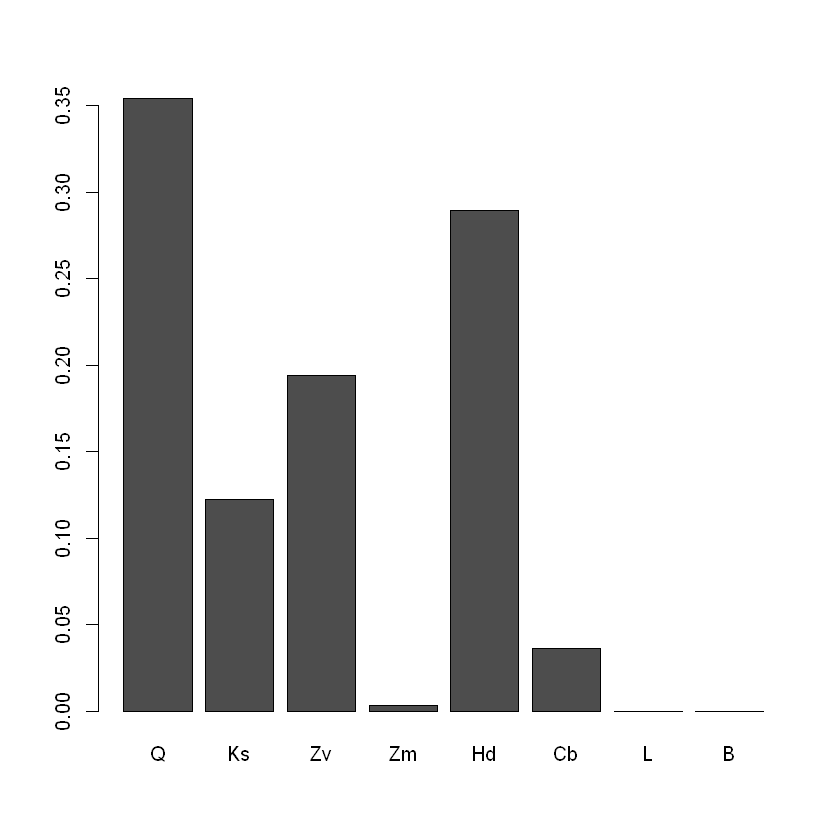

```r
#-----------------------------------------------------------------------------#
# Calcul des mesures d'importance (MI) par cumul quadratique
cum <- DF[1]^2*sigQ^2+DF[2]^2*sigKs^2+DF[3]^2*sigZv^2+DF[4]^2*sigZm^2+DF[5]^2*sigHd^2+DF[6]^2*sigCb^2+DF[7]^2*sigL^2+DF[8]^2*sigB^2

MI <- c(DF[1]^2*sigQ^2/cum,DF[2]^2*sigKs^2/cum,DF[3]^2*sigZv^2/cum,DF[4]^2*sigZm^2/cum,DF[5]^2*sigHd^2/cum,DF[6]^2*sigCb^2/cum,DF[7]^2*sigL^2/cum,DF[8]^2*sigB^2/cum)

MI <- matrix(c(MI),ncol=d,dimnames=list(c("MI"),names))
cat("-------->  Calcul des Mesures d'importance par  cumul quadratique : \n")
print(MI)
barplot(MI)
```

## 3. Méthode de Morris

Appliquez la méthode de Morris (sur les sorties $S$ et $C_{digue}$) (fonction `morris` du package `sensitivity`) avec un nombre de niveaux égal à 4 et un nombre de répétitions du plan OAT égal à 10. Testez d'autres configurations. Pour la borne supérieure de la variable $K_s$, on prendra le quantile à $95 \%$. Interprétez les résultats.

```
-------->  Méthode de Morris pour la surverse S :

Call:
morris(model = Fcrues, factors = names, r = 10, design = list(type = "oat",     levels = 4, grid.jump = 1), binf = binf, bsup = bsup, scale = TRUE,     ans = 1)

Model runs: 90
            mu    mu.star        sigma
Q   2.57198515 2.57198515 5.072930e-01
Ks -2.32483176 2.32483176 1.451930e+00
Zv  2.42524591 2.42524591 2.497695e-01
Zm -0.42718416 0.42718416 2.623882e-01
Hd -2.00000000 2.00000000 1.098417e-14
Cb -1.00000000 1.00000000 0.000000e+00
L   0.00419011 0.00419011 2.378559e-03
B  -0.07487041 0.07487041 3.443826e-02
```

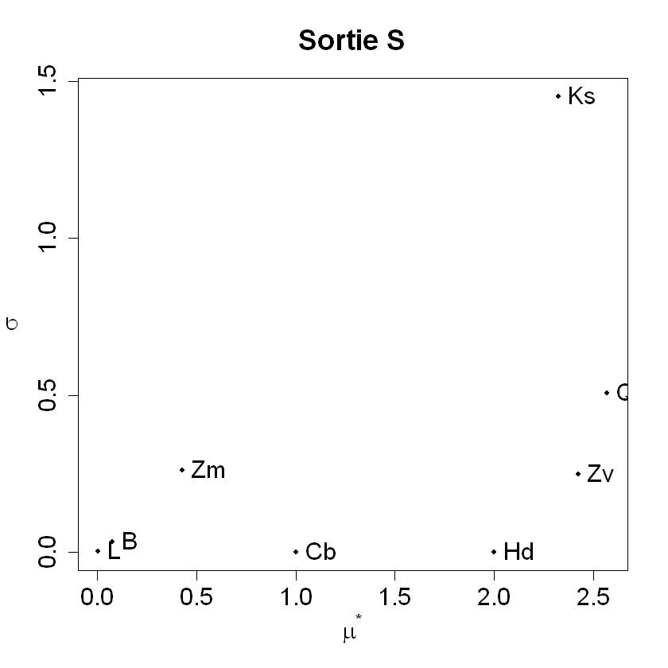

```r
# help(package="sensitivity")
# ?morris # fonction implémentant la méthode OAT de Morris

# pour la borne sup de Ks on prend le quantile a 95%

#-----------------------------------------------------------------------------#
# Pour la surverse S
cat("-------->  Méthode de Morris pour la surverse S : \n")
mor <- morris(model=Fcrues,ans=1,factors=names,design=list(type="oat",levels=4,grid.jump=1),r=10,
	binf=binf,bsup=bsup,scale = TRUE)
print(mor)
par(ps=18)
plot(mor, main="Sortie S")  # Réalisation du graphe de Morris
```

```
-------->  Méthode de Morris pour le Coût de la digue :

Call:
morris(model = Fcrues, factors = names, r = 5, design = list(type = "oat",     levels = 4, grid.jump = 1), binf = binf, bsup = bsup, scale = TRUE,     ans = 2)

Model runs: 45
              mu      mu.star        sigma
Q   0.0576831026 0.0576831026 0.0383585850
Ks -0.0499870655 0.0499870655 0.0457814433
Zv  0.0850628712 0.0850628712 0.0781079568
Zm -0.0167601905 0.0167601905 0.0155402119
Hd -0.0166641095 0.0561934007 0.0933716784
Cb -0.0354470162 0.0354470162 0.0261388368
L   0.0001548231 0.0001548231 0.0001412637
B  -0.0024989779 0.0024989779 0.0023692305
```

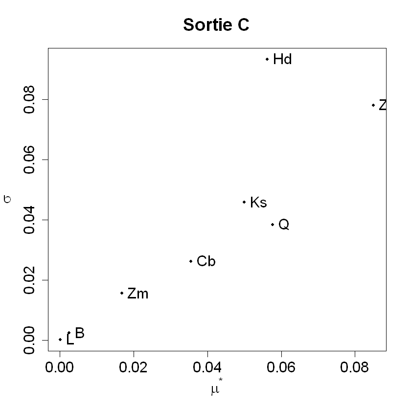

```r
#-----------------------------------------------------------------------------#
# Pour le cout de la digue Cp
mor <- morris(model=Fcrues,ans=2,factors=names,design=list(type="oat",levels=4,grid.jump=1),r=5,
	binf=binf,bsup=bsup,scale = TRUE)
cat("-------->  Méthode de Morris pour le Coût de la digue : \n")
print(mor)
par(ps=18)
plot(mor, main = "Sortie C") # Réalisation du graphe de Morris
```

## 4. Indices basés sur la corrélation/régression

2.4.a) Générez un échantillon aléatoire du vecteur d'entrées $X$ de taille n=1000 en utilisant la fonction `EchantFcrues()`, puis évaluer les réponses $S$ et $C_{digue}$ du modèle `Fcrues()` de cet échantillon. Tracer sur le même graphique les scatterplots entre chaque sortie et les entrées du modèle.

```
Taille de l'echantillon MOnte Carlo =  1000
```

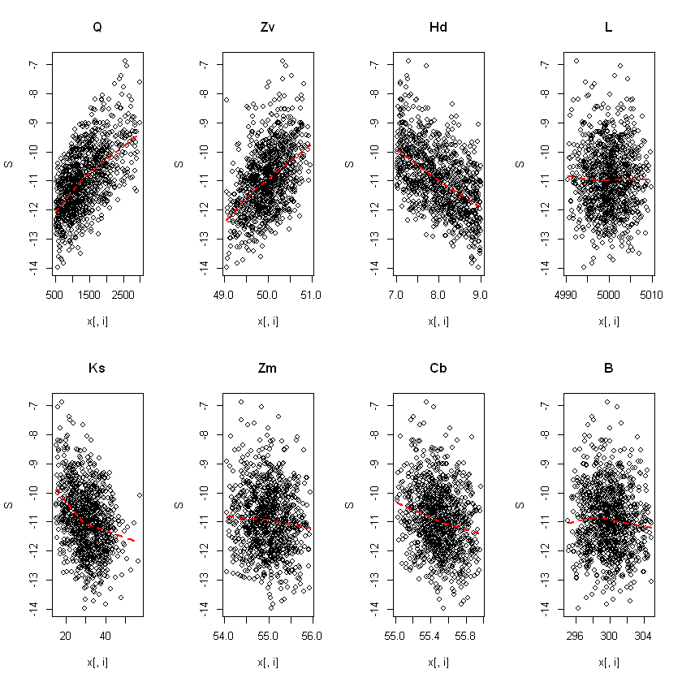

```r
N <- 1000
cat("Taille de l'echantillon MOnte Carlo = ",N)

x <- EchantFcrues(N)      # creation de l'echantillon
x <- matrix(c(x),ncol=d,dimnames=list(1:N,names))
z <- Fcrues(x) # Calcul des reponses du modele

#-----------------------------------------------------------------------------#
# Scatter plot pour la sortie Surverse
par(mfcol=c(2,4))
for (i in 1:d){
  plot(x[,i],z[,1], main=names[i], ylab = 'S')
  lines(lowess(x[,i],z[,1]), col = 2, lty = 2, lwd = 2) #Superposition d'une approximation par polynomes locaux
}
```

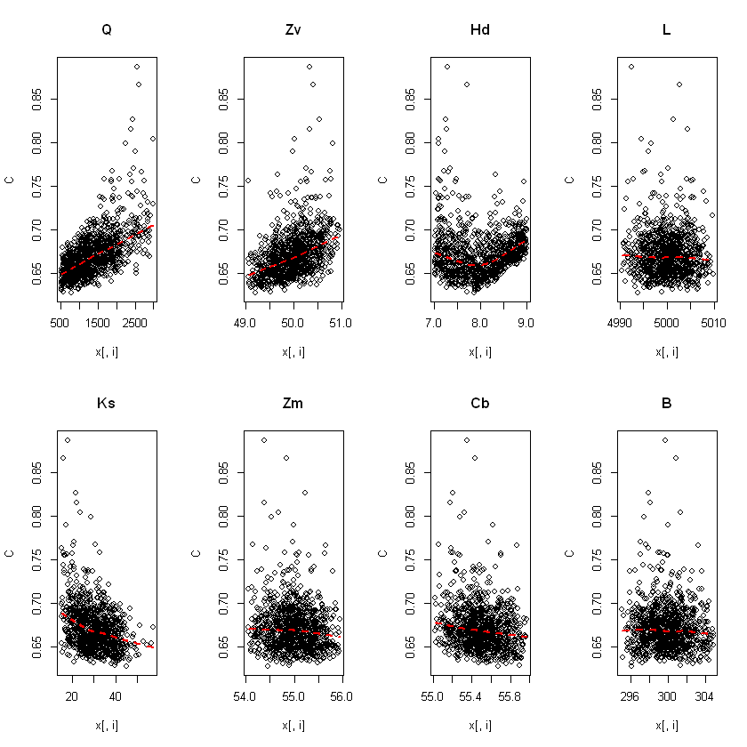

```r
# Scatter plot pour la sortie Cout de la digue
par(mfcol=c(2,4))
for (i in 1:d){
  plot(x[,i],z[,2], main=names[i],ylab = 'C')
  lines(lowess(x[,i],z[,2]), col = 2, lty = 2, lwd = 2) #Superposition d'une approximation par polynomes locaux
}
```

2.4.b) On veut tester la validité de la linéarité de la relation sortie/entrées. Ecrivez la formule du modèle linéaire suivant (la régression linéaire sera vue plus en détail dans le cours 5 et TD5) :

$$ Y= \beta _0+ \beta _1 Q + \beta _2 K_{s} + \beta _3 Z_{v} + \beta _4 Z_{m} + \beta _5 H_d + \beta _6 C_b + \beta _7 L + \beta _8 B $$

Commande R : `formule = as.formula(Y ~ Q Ks + Zv + Zm + Hd + Cb + L + B)`

Et effectuez une régression linéaire entre chacune des 2 sorties et les 8 entrées. Commande R : `modele = lm(formule,data=data.frame(x,y=z))`

Analysez ce modèle linéaire pour $S$ et $C_{digue}$ (fonctions `print()`, `summary()` et `plot()`). Pour chaque sortie, donnez la valeur du $R^2$ (part de variance de la sortie expliquée par le modèle linéaire) et faites un graphe des valeurs prédites en fonction des valeurs observées.  
Les relations sont-elles linéaires ? Si oui, calculez les coefficients de régression standard (SRC) et les indices de sensibilité associés (SRC2). Comparez-les avec les mesures d'importance issues du cumul quadratique.

```
######################################################################
-------->  Construction du modèle linéaire pour la surverse :

Call:
lm(formula = formule, data = data.frame(x, y = S))

Coefficients:
(Intercept)            Q           Ks           Zv           Zm           Hd
 10.7316180    0.0011278   -0.0536774    1.1415732   -0.1636712   -1.0106004
         Cb            L            B
 -1.0205702   -0.0005779   -0.0067549
```

1. 'coefficients'

2. 'residuals'

3. 'effects'

4. 'rank'

5. 'fitted.values'

6. 'assign'

7. 'qr'

8. 'df.residual'

9. 'xlevels'

10. 'call'

11. 'terms'

12. 'model'

```
Call:
lm(formula = formule, data = data.frame(x, y = S))

Residuals:
     Min       1Q   Median       3Q      Max
-0.40180 -0.07825 -0.01879  0.06240  0.89115

Coefficients:
              Estimate Std. Error  t value Pr(>|t|)
(Intercept)  1.073e+01  6.331e+00    1.695  0.09038 .
Q            1.128e-03  8.589e-06  131.308  < 2e-16 ***
Ks          -5.368e-02  6.604e-04  -81.278  < 2e-16 ***
Zv           1.142e+00  1.218e-02   93.761  < 2e-16 ***
Zm          -1.637e-01  1.224e-02  -13.370  < 2e-16 ***
Hd          -1.011e+00  8.657e-03 -116.744  < 2e-16 ***
Cb          -1.021e+00  2.433e-02  -41.954  < 2e-16 ***
L           -5.779e-04  1.222e-03   -0.473  0.63633
B           -6.755e-03  2.385e-03   -2.833  0.00471 **
---
Signif. codes:  0 '***' 0.001 '**' 0.01 '*' 0.05 '.' 0.1 ' ' 1

Residual standard error: 0.1548 on 991 degrees of freedom
Multiple R-squared:  0.9805,	Adjusted R-squared:  0.9804
F-statistic:  6236 on 8 and 991 DF,  p-value: < 2.2e-16
```

1. 'call'

2. 'terms'

3. 'residuals'

4. 'coefficients'

5. 'aliased'

6. 'sigma'

7. 'df'

8. 'r.squared'

9. 'adj.r.squared'

10. 'fstatistic'

11. 'cov.unscaled'

```
######################################################################
-------->  Validation du modèle linéaire pour la surverse :
         - Coefficient de détermination R2 =  0.9805234

 ######################################################################
-------->  Indices de sensibilite lineaire SRC2 pour la surverse :
             Q        Ks        Zv          Zm        Hd        Cb           L
SRC2 0.3420069 0.1309305 0.1738958 0.003550288 0.2700529 0.0348823 4.41357e-06
                B
SRC2 0.0001590919
```

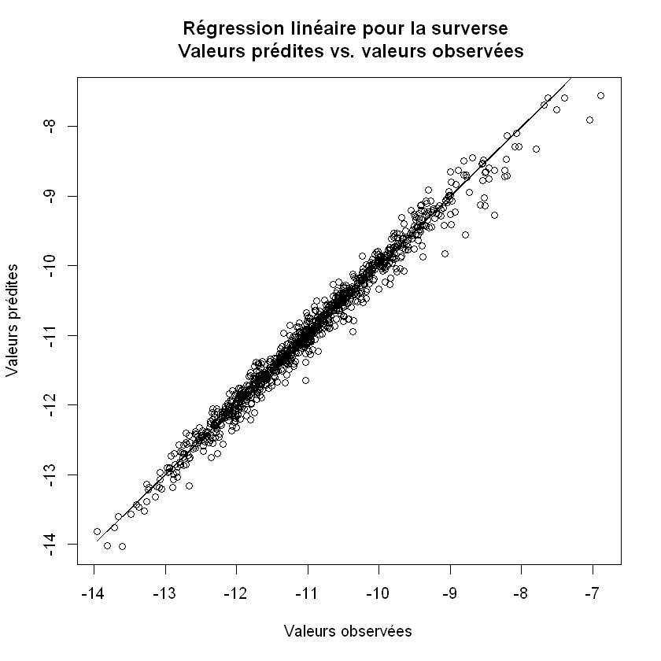

```r
# Regression linéaire de la fonction de S
  cat("######################################################################\n")
  cat("-------->  Construction du modèle linéaire pour la surverse : \n")
  S=z[,1]
  x <- matrix(c(x),ncol=d,dimnames=list(1:N,names))
  formule <- as.formula( S ~ Q + Ks + Zv + Zm + Hd + Cb + L + B)
  modele <- lm(formule,data=data.frame(x,y=S))
  print(modele)
  names(modele)

  # Analyse des t-values (tests sur coef)
  summary(modele)
  names(summary(modele))

# Validation du modèle linéaire par analyse graphique de la regression
  cat("######################################################################\n")
  cat("-------->  Validation du modèle linéaire pour la surverse : \n")
  y <- predict(modele,as.data.frame(x))
  plot(S,y, main = "Régression linéaire pour la surverse \n Valeurs prédites vs. valeurs observées", xlab="Valeurs observées",ylab="Valeurs prédites");
  lines(S,S)

  # Validation du modèle linéaire parCalcul du coefficient de determination (R2)
  R2 <- summary(modele)$r.squared
  cat("         - Coefficient de détermination R2 = ", R2," \n")

  cat("\n ######################################################################\n")
  cat("-------->  Indices de sensibilite lineaire SRC2 pour la surverse : \n")
  # Calcul des SRC^2
  a<-modele$coefficients
  src2 <- rep(0,d)
  for (i in 1:d) src2[i] <- a[i+1]^2*var(x[,i])/var(S)
  src2 <- matrix(c(src2),ncol=d,dimnames=list(c("SRC2"),names))
  print(src2)
```

```
######################################################################
-------->  Construction du modèle linéaire pour le Cout :

Call:
lm(formula = formule, data = data.frame(x, y = Cp))

Coefficients:
(Intercept)            Q           Ks           Zv           Zm           Hd
  1.905e+00    2.779e-05   -1.362e-03    2.501e-02   -3.614e-03    2.219e-03
         Cb            L            B
 -2.330e-02   -1.745e-04   -4.431e-04
```

1. 'coefficients'

2. 'residuals'

3. 'effects'

4. 'rank'

5. 'fitted.values'

6. 'assign'

7. 'qr'

8. 'df.residual'

9. 'xlevels'

10. 'call'

11. 'terms'

12. 'model'

```
Call:
lm(formula = formule, data = data.frame(x, y = Cp))

Residuals:
      Min        1Q    Median        3Q       Max
-0.025554 -0.009604 -0.001720  0.005672  0.151246

Coefficients:
              Estimate Std. Error t value Pr(>|t|)
(Intercept)  1.905e+00  6.173e-01   3.085  0.00209 **
Q            2.779e-05  8.375e-07  33.183  < 2e-16 ***
Ks          -1.362e-03  6.439e-05 -21.149  < 2e-16 ***
Zv           2.501e-02  1.187e-03  21.069  < 2e-16 ***
Zm          -3.614e-03  1.194e-03  -3.028  0.00253 **
Hd           2.219e-03  8.440e-04   2.629  0.00871 **
Cb          -2.330e-02  2.372e-03  -9.822  < 2e-16 ***
L           -1.745e-04  1.191e-04  -1.465  0.14324
B           -4.431e-04  2.325e-04  -1.906  0.05696 .
---
Signif. codes:  0 '***' 0.001 '**' 0.01 '*' 0.05 '.' 0.1 ' ' 1

Residual standard error: 0.01509 on 991 degrees of freedom
Multiple R-squared:  0.6863,	Adjusted R-squared:  0.6838
F-statistic: 271.1 on 8 and 991 DF,  p-value: < 2.2e-16
```

1. 'call'

2. 'terms'

3. 'residuals'

4. 'coefficients'

5. 'aliased'

6. 'sigma'

7. 'df'

8. 'r.squared'

9. 'adj.r.squared'

10. 'fstatistic'

11. 'cov.unscaled'

```
######################################################################
-------->  Validation du modèle linéaire pour le cout :
         - Coefficient de détermination R2 =  0.6863376

 ######################################################################
-------->  Indices de sensibilite lineaire SRC2 pour le Cout :
                Q           Ks           Zv           Zm           Hd
SRC2 0.0002076422 8.427576e-05 8.347486e-05 1.730923e-06 1.301563e-06
               Cb            L            B
SRC2 1.817665e-05 4.025327e-07 6.846193e-07
```

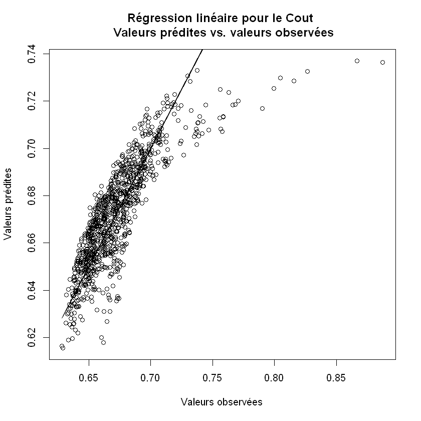

```r
#Regression linéaire de la fonction de Cp
  cat("######################################################################\n")
  cat("-------->  Construction du modèle linéaire pour le Cout : \n")
  Cp=z[,2]
  x <- matrix(c(x),ncol=d,dimnames=list(1:N,names))
  formule <- as.formula( Cp ~ Q + Ks + Zv + Zm + Hd + Cb + L + B)
  modele <- lm(formule,data=data.frame(x,y=Cp))
  print(modele)
  names(modele)

  # Analyse des t-values (tests sur coef)
  summary(modele)
  names(summary(modele))

# Validation du modèle linéaire par analyse graphique de la regression
  cat("######################################################################\n")
  cat("-------->  Validation du modèle linéaire pour le cout : \n")
  y <- predict(modele,as.data.frame(x))
  plot(Cp,y, main = "Régression linéaire pour le Cout \n Valeurs prédites vs. valeurs observées", xlab="Valeurs observées",ylab="Valeurs prédites") ;
  lines(Cp,Cp)

  # Validation du modèle linéaire parCalcul du coefficient de determination (R2)
  R2 <- summary(modele)$r.squared
  cat("         - Coefficient de détermination R2 = ", R2," \n")

  cat("\n ######################################################################\n")
  cat("-------->  Indices de sensibilite lineaire SRC2 pour le Cout : \n")
  # Calcul des SRC^2
  a<-modele$coefficients
  src2 <- rep(0,d)
  for (i in 1:d) src2[i] <- a[i+1]^2*var(x[,i])/var(S)
  src2 <- matrix(c(src2),ncol=d,dimnames=list(c("SRC2"),names))
  print(src2)
```

## 5. Indices de Sobol

2.5.a) A l'aide de la fonction `sobol2002()` du package `sensitivity`, calculez les indices de Sobol de la sortie $C_{digue}$.

On prendra comme entrée de cette fonction 2 échantillons Monte Carlo indépendants $X^{(1)}$ et $X^{(2)}$ de taille 10000. Il est conseillé d'incrémenter le paramètre `nboot` afin d'avoir un intervalle de confiance sur les estimations.

Analysez les résultats avec les fonctions `print()` et `plot()`. Si les résultats ne vous semblent pas satisfaisants, augmentez la taille des échantillons Monte Carlo pour augmenter la précision des indices tant que les calculs restent possibles (des problèmes de coûts en temps de calcul et de mémoire vive peuvent se poser).

On rappelle la formule d'estimation du numérateur de l'indice de Sobol au premier ordre :

$$ \hat{V_k}=\frac{1}{n}\sum_{i=1}^{n} g(X_{i,1}^{(2)},..., X_{i,d}^{(2)})g(X_{i,1}^{(1)},..., X_{i,k-1}^{(1)},X_{i,k-1}^{(2)},X_{i,k+1}^{(1)},...X_{i,d}^{(1)})\ - \ \left (\frac{1}{n}\sum_{i=1}^{n} g(X_{i,1}^{(1)},..., X_{i,d}^{(1)})\right)^2 $$

Le numérateur de l'indice de Sobol total est estimé par :

$$ \hat{V_{-k}}=\frac{1}{n}\sum_{i=1}^{n} g(X_{i,1}^{(1)},..., X_{i,d}^{(1)})g(X_{i,1}^{(1)},..., X_{i,k-1}^{(1)},X_{i,k-1}^{(2)},X_{i,k+1}^{(1)},...X_{i,d}^{(1)})\ - \ \left (\frac{1}{n}\sum_{i=1}^{n} g(X_{i,1}^{(1)},..., X_{i,d}^{(1)})\right)^2 $$

Le dénominateur de l'indice au premier ordre et total est estimé par :

$$ \hat{V_{-k}}=\frac{1}{n}\sum_{i=1}^{n} \left (g(X_{i,1}^{(1)},..., X_{i,d}^{(1)})\right)^2\ - \ \left (\frac{1}{n}\sum_{i=1}^{n} g(X_{i,1}^{(1)},..., X_{i,d}^{(1)})\right)^2 $$

[output not shown]

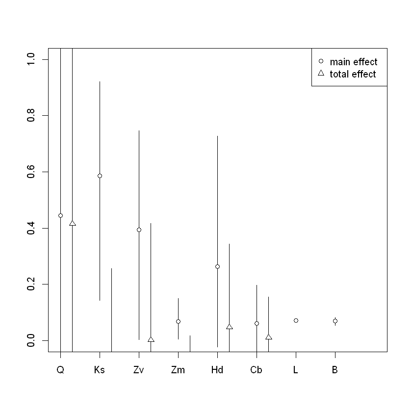

```r
# help(package="sensitivity")
# ?sobol2002 # fonction implémentant le calcul des indices de Sobol
set.seed(12345)

n <- 1e4 # 1ere essai
#n <- 1e5 # 2eme essai
n2 <- 2*n # taille echantillon total
# creation des deux echantillons Monte Carlo pour le calcul des indices de Sobol
xs <- EchantFcrues(n2)
xs <- matrix(xs,ncol=d,dimnames=list(1:n2,names))
xs1 = xs[1:n,]
xs2 = xs[(n+1):(2*n),]

cat("######################################################################\n")
cat("-------->  Calcul des indices de Sobol avec fonction Sobol2002 : \n")
sa = sobol2002(model = Fcrues, ans=2, X1 = xs1, X2 = xs2, nboot=100)

print(sa)
plot(sa)
```

2.5.b) Effectuez la même analyse avec les fonctions `sobol2007()` et `soboljansen()` qui codent des formules plus précises pour le numérateur des indices de Sobol :

```
######################################################################
-------->  Calcul des indices de Sobol avec fonction Soboljansen :

Call:
soboljansen(model = Fcrues, X1 = xs1, X2 = xs2, nboot = 100,     ans = 2)

Model runs: 100000

First order indices:
      original         bias std. error   min. c.i.  max. c.i.
Q   0.34695240 -0.002058151 0.02815063  0.29309160 0.41615365
Ks  0.11482506 -0.003153508 0.03324833  0.04773011 0.19475699
Zv  0.15219710 -0.004131343 0.02889646  0.10246387 0.22290053
Zm -0.01268388 -0.004033529 0.02872983 -0.06254514 0.05459211
Hd  0.10616843 -0.003957456 0.02948916  0.05830670 0.17274773
Cb  0.01466564 -0.003200846 0.02634247 -0.03254100 0.07161534
L  -0.01838214 -0.003446655 0.02789623 -0.06860617 0.04218239
B  -0.01750741 -0.003427473 0.02803066 -0.06747279 0.04281299

Total indices:
       original          bias   std. error    min. c.i.    max. c.i.
Q  4.990254e-01  1.525365e-03 1.676159e-02 4.552114e-01 5.287627e-01
Ks 2.541362e-01 -5.121480e-04 8.559331e-03 2.342592e-01 2.695290e-01
Zv 2.255041e-01  7.799932e-04 7.098040e-03 2.088307e-01 2.375618e-01
Zm 7.862186e-03  5.075490e-05 5.518756e-04 6.456617e-03 8.884012e-03
Hd 1.869178e-01  5.167605e-04 5.793032e-03 1.752881e-01 1.991865e-01
Cb 4.047539e-02  7.394808e-05 1.248480e-03 3.780598e-02 4.258605e-02
L  6.867612e-07 -2.746853e-10 2.174695e-08 6.488871e-07 7.317803e-07
B  1.842282e-04  7.726785e-07 6.882258e-06 1.710707e-04 1.992012e-04
```

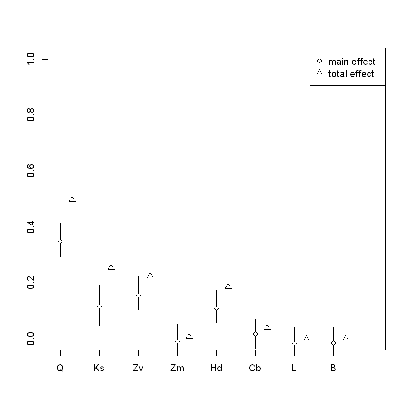

```r
#-----------------------------------------------------------------------------#
# ?soboljansen

set.seed(12345)

n <- 1e4
n2 <- 2*n # taille echantillon total
# creation des deux echantillons Monte Carlo pour le calcul des indices de Sobol
xs <- EchantFcrues(n2)
xs <- matrix(xs,ncol=d,dimnames=list(1:n2,names))
xs1 = xs[1:n,]
xs2 = xs[(n+1):(2*n),]

cat("######################################################################\n")
cat("-------->  Calcul des indices de Sobol avec fonction Soboljansen : \n")
sa <- soboljansen(model = Fcrues, ans=2, X1 = xs1, X2 = xs2, nboot=100)

print(sa)
plot(sa)
```

2.5.c) La convergence des indices de Sobol étant très lentes avec des échantillons Monte Carlo, changez de type d'échantillons dans les entrées de la fonction `soboljansen()` en prenant une taille de 1000 et des échantillons quasi-Monte Carlo telles que des séquences de Sobol (fonction `sobol` du package `randtoolbox`). Ces suites ont été vues dans le Cours et TD 2 sur la planification d'expériences numériques.

La seule contrainte est que ces 2 échantillons doivent être indépendants (une astuce doit être trouvée) et que les variables simulées suivent les bonnes lois (cf. fichier `EchantFcrues.R`).

Il faudra transformer les variables $\mathcal{U}[0; 1]$ en leur loi respective par :

```
X[,i] = qloi(X[,i],param1=,param2=,...)
Par exemple : X[,2] = qtnorm(X[,2],mean=30.0,sd=8,min=15.)
```

```
Call:
soboljansen(model = Fcrues, X1 = xs1, X2 = xs2, ans = 2)

Model runs: 10000

First order indices:
     original
Q  0.37203699
Ks 0.15899918
Zv 0.21054577
Zm 0.02548392
Hd 0.17360644
Cb 0.09004897
L  0.03136088
B  0.03110014

Total indices:
       original
Q  4.571796e-01
Ks 3.042892e-01
Zv 2.180340e-01
Zm 8.911552e-03
Hd 1.707602e-01
Cb 4.271868e-02
L  7.429211e-07
B  1.834975e-04
```

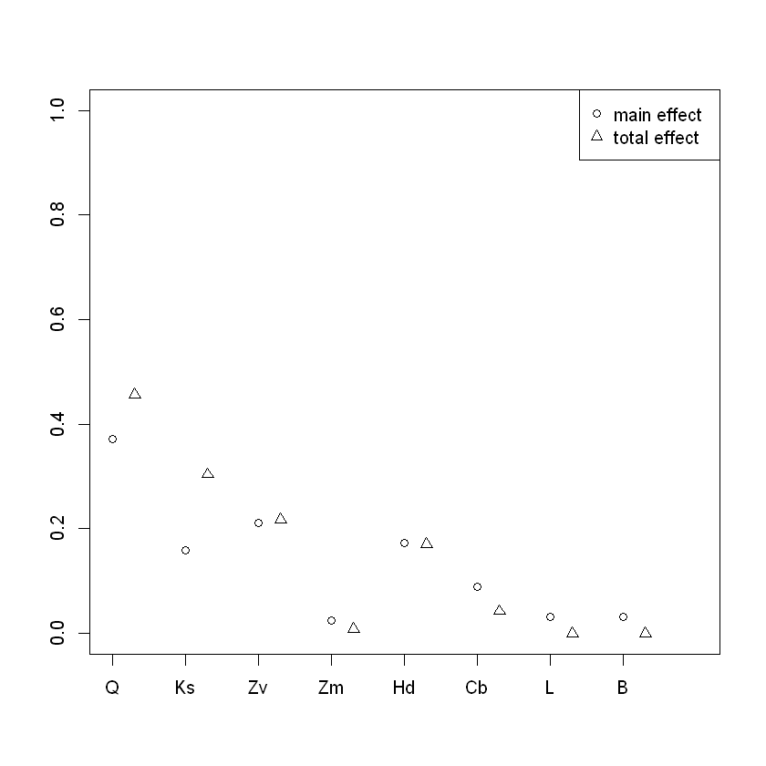

```r
n = 1000
# creation des deux echantillons avec la suite de Sobol'
xs <- randtoolbox::sobol(n,16,scrambling=1)
X = rbind(xs[,1:8],xs[,9:16])

X[,1] = qtgumbel(X[,1],loc=1013.0,scale=558.0,min=500,max=3000)
X[,2] = qtnorm(X[,2],mean=30.0,sd=8,min=15.)
X[,3] = qtriangle(X[,3],a=49,b=51,c=50)
X[,4] = qtriangle(X[,4],a=54,b=56,c=55)
X[,5] = qunif(X[,5],min=7,max=9)
X[,6] = qtriangle(X[,6],a=55,b=56,c=55.5)
X[,7] = qtriangle(X[,7],a=4990,b=5010,c=5000)
X[,8] = qtriangle(X[,8],a=295,b=305,c=300)

xs1 = matrix(X[1:n,],ncol=d,dimnames=list(1:n,names))
n1=n+1 ; n2=2*n
xs2 = matrix(X[n1:n2,],ncol=d,dimnames=list(1:n,names))

sa2 <- soboljansen(model = Fcrues, ans=2, X1=xs1, X2=xs2)

print(sa2)
plot(sa2)
```